# FinalFinal

Step 1: Import Libraires and Database

```python
import pandas as pd
import numpy as np
import seaborn as sns
import matplotlib.pyplot as plt
```

```python
df = pd.read_csv('https://raw.githubusercontent.com/delinai/schulich_ds1_2024/main/Datasets/Assignment1_StreamFlow_Subscription_Data.csv')
```

STEP 2: Conduct Exploratory Analysis

- Look at main features of the Data
- Check if Data must be cleaned (ie. missing values)

```python
# look at the columns and first 20 rows of data
df.head(20)
```

|  | User_ID | Age | Gender | Location | Subscription_Start_Date | Subscription_Type | Monthly_Payment | Payment_Method | Monthly_Hours_Watched | Favorite_Genre | Devices_Used | Average_Session_Length | Content_ID | Rating_Given | Churned | Date_of_Churn | Reason_for_Churn |
| --- | --- | --- | --- | --- | --- | --- | --- | --- | --- | --- | --- | --- | --- | --- | --- | --- | --- |
| 0 | 1 | 56 | Other | Central | 2020-06-07 01:53:37.656934 | Premium | 19.99 | Credit Card | 31.513153 | Action | PC | 1.195762 | 1023 | 5 | 0 | NaN | NaN |
| 1 | 2 | 69 | Other | West | 2024-02-21 01:53:37.656980 | Standard | 14.99 | Credit Card | 4.982277 | Drama | PC | 0.809002 | 1076 | 1 | 0 | NaN | NaN |
| 2 | 3 | 46 | Female | North | 2022-10-06 01:53:37.656995 | Standard | 14.99 | PayPal | 4.114953 | Sci-Fi | Tablet | 1.153570 | 1095 | 2 | 0 | NaN | NaN |
| 3 | 4 | 32 | Female | East | 2022-01-04 01:53:37.657006 | Standard | 14.99 | Credit Card | 60.244820 | Action | TV | 0.609503 | 1003 | 1 | 0 | NaN | NaN |
| 4 | 5 | 60 | Female | North | 2020-03-13 01:53:37.657017 | Standard | 14.99 | Credit Card | 4.711855 | Sci-Fi | Mobile | 0.359971 | 1012 | 4 | 0 | NaN | NaN |
| 5 | 6 | 25 | Other | South | 2023-10-26 01:53:37.657028 | Basic | 9.99 | PayPal | 6.046944 | Drama | Tablet | 2.336847 | 1072 | 5 | 0 | NaN | NaN |
| 6 | 7 | 38 | Female | Central | 2021-02-06 01:53:37.657039 | Basic | 9.99 | Direct Debit | 69.876742 | Comedy | TV | 1.445445 | 1056 | 4 | 0 | NaN | NaN |
| 7 | 8 | 56 | Female | North | 2023-05-26 01:53:37.657051 | Basic | 9.99 | Credit Card | 26.538526 | Drama | TV | 0.446673 | 1097 | 4 | 0 | NaN | NaN |
| 8 | 9 | 36 | Male | East | 2021-09-29 01:53:37.657064 | Standard | 14.99 | Credit Card | 24.052576 | Drama | PC | 0.770118 | 1036 | 2 | 0 | NaN | NaN |
| 9 | 10 | 40 | Female | West | 2020-07-22 01:53:37.657075 | Basic | 9.99 | PayPal | 38.336441 | Drama | TV | 1.792035 | 1047 | 4 | 0 | NaN | NaN |
| 10 | 11 | 28 | Female | West | 2019-06-10 01:53:37.657086 | Standard | 14.99 | PayPal | 2.461962 | Documentary | Mobile | 0.149941 | 1070 | 2 | 0 | NaN | NaN |
| 11 | 12 | 28 | Other | East | 2019-12-12 01:53:37.657097 | Premium | 19.99 | Credit Card | 24.480533 | Sci-Fi | TV | 0.319054 | 1000 | 5 | 0 | NaN | NaN |
| 12 | 13 | 41 | Other | North | 2021-04-22 01:53:37.657108 | Standard | 14.99 | Direct Debit | 14.011035 | Sci-Fi | Mobile | 0.152133 | 1059 | 5 | 1 | 2021-06-13 01:53:37.657108 | Found better service |
| 13 | 14 | 70 | Other | South | 2020-10-29 01:53:37.657119 | Standard | 14.99 | Direct Debit | 35.339461 | Sci-Fi | Mobile | 3.346005 | 1011 | 2 | 1 | 2021-03-11 01:53:37.657119 | Found better service |
| 14 | 15 | 53 | Other | East | 2023-10-06 01:53:37.657130 | Standard | 14.99 | Credit Card | 14.191293 | Documentary | Mobile | 2.791956 | 1020 | 1 | 1 | 2024-07-02 01:53:37.657130 | Price increase |
| 15 | 16 | 57 | Other | North | 2019-09-22 01:53:37.657140 | Premium | 19.99 | Credit Card | 19.364387 | Comedy | Tablet | 2.799269 | 1010 | 5 | 0 | NaN | NaN |
| 16 | 17 | 41 | Other | South | 2019-07-27 01:53:37.657151 | Premium | 19.99 | Credit Card | 12.991876 | Drama | Mobile | 2.519855 | 1043 | 1 | 1 | 2020-03-16 01:53:37.657151 | Found better service |
| 17 | 18 | 20 | Female | North | 2022-10-12 01:53:37.657161 | Premium | 19.99 | PayPal | 13.007844 | Comedy | Mobile | 2.213604 | 1057 | 5 | 0 | NaN | NaN |
| 18 | 19 | 39 | Other | North | 2022-03-19 01:53:37.657172 | Premium | 19.99 | Credit Card | 29.217770 | Documentary | Mobile | 1.296317 | 1043 | 5 | 0 | NaN | NaN |
| 19 | 20 | 70 | Other | South | 2023-08-19 01:53:37.657189 | Basic | 9.99 | PayPal | 19.807703 | Sci-Fi | Mobile | 2.055999 | 1077 | 3 | 0 | NaN | NaN |

From this I conclude

- Date of churn shown as NAN for those that do not churn
- customers that churned given 1 value not churned given zero
- there are 16 columns which are possible factors contributing to churn

```python
# Look at the main statisitcal Properties of the numerical database
df.describe()
```

|  | User_ID | Age | Monthly_Payment | Monthly_Hours_Watched | Average_Session_Length | Content_ID | Rating_Given | Churned |
| --- | --- | --- | --- | --- | --- | --- | --- | --- |
| count | 1000.000000 | 1000.000000 | 1000.000000 | 1000.000000 | 1000.000000 | 1000.000000 | 1000.000000 | 1000.000000 |
| mean | 500.500000 | 44.385000 | 14.580000 | 19.071653 | 1.893771 | 1049.201000 | 3.030000 | 0.246000 |
| std | 288.819436 | 15.321669 | 3.404922 | 19.279140 | 1.868852 | 29.268058 | 1.422365 | 0.430894 |
| min | 1.000000 | 18.000000 | 9.990000 | 0.041574 | 0.000486 | 1000.000000 | 1.000000 | 0.000000 |
| 25% | 250.750000 | 31.750000 | 9.990000 | 5.490739 | 0.548918 | 1023.000000 | 2.000000 | 0.000000 |
| 50% | 500.500000 | 45.000000 | 14.990000 | 13.361219 | 1.271808 | 1048.000000 | 3.000000 | 0.000000 |
| 75% | 750.250000 | 57.000000 | 14.990000 | 26.471636 | 2.623575 | 1075.000000 | 4.000000 | 0.000000 |
| max | 1000.000000 | 70.000000 | 19.990000 | 139.170408 | 11.417557 | 1099.000000 | 5.000000 | 1.000000 |

```python
# Identify Missing Values in each coloumn (NAN)
df.isnull().sum()
```

```
User_ID                      0
Age                          0
Gender                       0
Location                     0
Subscription_Start_Date      0
Subscription_Type            0
Monthly_Payment              0
Payment_Method               0
Monthly_Hours_Watched        0
Favorite_Genre               0
Devices_Used                 0
Average_Session_Length       0
Content_ID                   0
Rating_Given                 0
Churned                      0
Date_of_Churn              754
Reason_for_Churn           754
dtype: int64
```

From this I conclude

- Confirm no pertantent missing values for data

```python
#main statistical properties for the categorical (object) columns
df.describe(include=['O'])
```

|  | Gender | Location | Subscription_Start_Date | Subscription_Type | Payment_Method | Favorite_Genre | Devices_Used | Date_of_Churn | Reason_for_Churn |
| --- | --- | --- | --- | --- | --- | --- | --- | --- | --- |
| count | 1000 | 1000 | 1000 | 1000 | 1000 | 1000 | 1000 | 246 | 246 |
| unique | 3 | 5 | 1000 | 3 | 3 | 5 | 4 | 246 | 4 |
| top | Other | West | 2020-06-07 01:53:37.656934 | Standard | Credit Card | Drama | Mobile | 2021-06-13 01:53:37.657108 | Price increase |
| freq | 336 | 216 | 1 | 530 | 613 | 212 | 408 | 1 | 68 |

From this I conclude

- No pertantent missing values for categorical data
- 246 people churned
- the different unique values in each column
- most frequent value in each column

```python
# Understanding the sturcture and type of data
df.info()
```

```
<class 'pandas.core.frame.DataFrame'>
RangeIndex: 1000 entries, 0 to 999
Data columns (total 17 columns):
 #   Column                   Non-Null Count  Dtype
---  ------                   --------------  -----
 0   User_ID                  1000 non-null   int64
 1   Age                      1000 non-null   int64
 2   Gender                   1000 non-null   object
 3   Location                 1000 non-null   object
 4   Subscription_Start_Date  1000 non-null   object
 5   Subscription_Type        1000 non-null   object
 6   Monthly_Payment          1000 non-null   float64
 7   Payment_Method           1000 non-null   object
 8   Monthly_Hours_Watched    1000 non-null   float64
 9   Favorite_Genre           1000 non-null   object
 10  Devices_Used             1000 non-null   object
 11  Average_Session_Length   1000 non-null   float64
 12  Content_ID               1000 non-null   int64
 13  Rating_Given             1000 non-null   int64
 14  Churned                  1000 non-null   int64
 15  Date_of_Churn            246 non-null    object
 16  Reason_for_Churn         246 non-null    object
dtypes: float64(3), int64(5), object(9)
memory usage: 132.9+ KB
```

From this I conclue

- confrim no missing data
- see the different data types (float, integer and object)
- see that Date_of_churn and Subscription_start_date given as object--> need to be changed into date time during data processing ste

STEP 3: Data Engineering

- Cleaning and Processing

```python
#turn Date_of_churn & Subscription_start_date into Datetime data
df['Date_of_Churn'] = pd.to_datetime(df['Date_of_Churn'])
df['Subscription_Start_Date'] = pd.to_datetime(df['Subscription_Start_Date'])
```

```python
#look at data type to ensure they have been converted
df.info()
```

```
<class 'pandas.core.frame.DataFrame'>
RangeIndex: 1000 entries, 0 to 999
Data columns (total 17 columns):
 #   Column                   Non-Null Count  Dtype
---  ------                   --------------  -----
 0   User_ID                  1000 non-null   int64
 1   Age                      1000 non-null   int64
 2   Gender                   1000 non-null   object
 3   Location                 1000 non-null   object
 4   Subscription_Start_Date  1000 non-null   datetime64[ns]
 5   Subscription_Type        1000 non-null   object
 6   Monthly_Payment          1000 non-null   float64
 7   Payment_Method           1000 non-null   object
 8   Monthly_Hours_Watched    1000 non-null   float64
 9   Favorite_Genre           1000 non-null   object
 10  Devices_Used             1000 non-null   object
 11  Average_Session_Length   1000 non-null   float64
 12  Content_ID               1000 non-null   int64
 13  Rating_Given             1000 non-null   int64
 14  Churned                  1000 non-null   int64
 15  Date_of_Churn            246 non-null    datetime64[ns]
 16  Reason_for_Churn         246 non-null    object
dtypes: datetime64[ns](2), float64(3), int64(5), object(7)
memory usage: 132.9+ KB
```

```python
#Add Sub_length column: this column will display the time with the subscription before churn
df['sub_length'] = (df['Date_of_Churn'] - df['Subscription_Start_Date']).dt.days
```

```python
#look at data t to ensure it has been added
df.head(25)
```

|  | User_ID | Age | Gender | Location | Subscription_Start_Date | Subscription_Type | Monthly_Payment | Payment_Method | Monthly_Hours_Watched | Favorite_Genre | Devices_Used | Average_Session_Length | Content_ID | Rating_Given | Churned | Date_of_Churn | Reason_for_Churn | sub_length |
| --- | --- | --- | --- | --- | --- | --- | --- | --- | --- | --- | --- | --- | --- | --- | --- | --- | --- | --- |
| 0 | 1 | 56 | Other | Central | 2020-06-07 01:53:37.656934 | Premium | 19.99 | Credit Card | 31.513153 | Action | PC | 1.195762 | 1023 | 5 | 0 | NaT | NaN | NaN |
| 1 | 2 | 69 | Other | West | 2024-02-21 01:53:37.656980 | Standard | 14.99 | Credit Card | 4.982277 | Drama | PC | 0.809002 | 1076 | 1 | 0 | NaT | NaN | NaN |
| 2 | 3 | 46 | Female | North | 2022-10-06 01:53:37.656995 | Standard | 14.99 | PayPal | 4.114953 | Sci-Fi | Tablet | 1.153570 | 1095 | 2 | 0 | NaT | NaN | NaN |
| 3 | 4 | 32 | Female | East | 2022-01-04 01:53:37.657006 | Standard | 14.99 | Credit Card | 60.244820 | Action | TV | 0.609503 | 1003 | 1 | 0 | NaT | NaN | NaN |
| 4 | 5 | 60 | Female | North | 2020-03-13 01:53:37.657017 | Standard | 14.99 | Credit Card | 4.711855 | Sci-Fi | Mobile | 0.359971 | 1012 | 4 | 0 | NaT | NaN | NaN |
| 5 | 6 | 25 | Other | South | 2023-10-26 01:53:37.657028 | Basic | 9.99 | PayPal | 6.046944 | Drama | Tablet | 2.336847 | 1072 | 5 | 0 | NaT | NaN | NaN |
| 6 | 7 | 38 | Female | Central | 2021-02-06 01:53:37.657039 | Basic | 9.99 | Direct Debit | 69.876742 | Comedy | TV | 1.445445 | 1056 | 4 | 0 | NaT | NaN | NaN |
| 7 | 8 | 56 | Female | North | 2023-05-26 01:53:37.657051 | Basic | 9.99 | Credit Card | 26.538526 | Drama | TV | 0.446673 | 1097 | 4 | 0 | NaT | NaN | NaN |
| 8 | 9 | 36 | Male | East | 2021-09-29 01:53:37.657064 | Standard | 14.99 | Credit Card | 24.052576 | Drama | PC | 0.770118 | 1036 | 2 | 0 | NaT | NaN | NaN |
| 9 | 10 | 40 | Female | West | 2020-07-22 01:53:37.657075 | Basic | 9.99 | PayPal | 38.336441 | Drama | TV | 1.792035 | 1047 | 4 | 0 | NaT | NaN | NaN |
| 10 | 11 | 28 | Female | West | 2019-06-10 01:53:37.657086 | Standard | 14.99 | PayPal | 2.461962 | Documentary | Mobile | 0.149941 | 1070 | 2 | 0 | NaT | NaN | NaN |
| 11 | 12 | 28 | Other | East | 2019-12-12 01:53:37.657097 | Premium | 19.99 | Credit Card | 24.480533 | Sci-Fi | TV | 0.319054 | 1000 | 5 | 0 | NaT | NaN | NaN |
| 12 | 13 | 41 | Other | North | 2021-04-22 01:53:37.657108 | Standard | 14.99 | Direct Debit | 14.011035 | Sci-Fi | Mobile | 0.152133 | 1059 | 5 | 1 | 2021-06-13 01:53:37.657108 | Found better service | 52.0 |
| 13 | 14 | 70 | Other | South | 2020-10-29 01:53:37.657119 | Standard | 14.99 | Direct Debit | 35.339461 | Sci-Fi | Mobile | 3.346005 | 1011 | 2 | 1 | 2021-03-11 01:53:37.657119 | Found better service | 133.0 |
| 14 | 15 | 53 | Other | East | 2023-10-06 01:53:37.657130 | Standard | 14.99 | Credit Card | 14.191293 | Documentary | Mobile | 2.791956 | 1020 | 1 | 1 | 2024-07-02 01:53:37.657130 | Price increase | 270.0 |
| 15 | 16 | 57 | Other | North | 2019-09-22 01:53:37.657140 | Premium | 19.99 | Credit Card | 19.364387 | Comedy | Tablet | 2.799269 | 1010 | 5 | 0 | NaT | NaN | NaN |
| 16 | 17 | 41 | Other | South | 2019-07-27 01:53:37.657151 | Premium | 19.99 | Credit Card | 12.991876 | Drama | Mobile | 2.519855 | 1043 | 1 | 1 | 2020-03-16 01:53:37.657151 | Found better service | 233.0 |
| 17 | 18 | 20 | Female | North | 2022-10-12 01:53:37.657161 | Premium | 19.99 | PayPal | 13.007844 | Comedy | Mobile | 2.213604 | 1057 | 5 | 0 | NaT | NaN | NaN |
| 18 | 19 | 39 | Other | North | 2022-03-19 01:53:37.657172 | Premium | 19.99 | Credit Card | 29.217770 | Documentary | Mobile | 1.296317 | 1043 | 5 | 0 | NaT | NaN | NaN |
| 19 | 20 | 70 | Other | South | 2023-08-19 01:53:37.657189 | Basic | 9.99 | PayPal | 19.807703 | Sci-Fi | Mobile | 2.055999 | 1077 | 3 | 0 | NaT | NaN | NaN |
| 20 | 21 | 19 | Male | North | 2022-05-08 01:53:37.657200 | Premium | 19.99 | PayPal | 20.062217 | Drama | Tablet | 0.078233 | 1097 | 4 | 0 | NaT | NaN | NaN |
| 21 | 22 | 41 | Female | East | 2023-07-29 01:53:37.657210 | Standard | 14.99 | Credit Card | 11.967015 | Action | Tablet | 1.942890 | 1033 | 4 | 0 | NaT | NaN | NaN |
| 22 | 23 | 61 | Female | West | 2019-10-09 01:53:37.657221 | Basic | 9.99 | PayPal | 15.147720 | Action | Mobile | 3.009054 | 1024 | 1 | 0 | NaT | NaN | NaN |
| 23 | 24 | 47 | Female | Central | 2020-04-07 01:53:37.657231 | Premium | 19.99 | Direct Debit | 27.386202 | Comedy | PC | 1.387728 | 1003 | 4 | 0 | NaT | NaN | NaN |
| 24 | 25 | 55 | Other | South | 2020-07-03 01:53:37.657242 | Basic | 9.99 | Credit Card | 34.967210 | Sci-Fi | TV | 0.884818 | 1063 | 1 | 0 | NaT | NaN | NaN |

STEP 4: Explore and understand the factors contributing to churn

- To find the relavent factors for churn that have an infuluence I will
  - run visualization of differnt factors agains churn and look at rate of churn between diffiernt values within each column

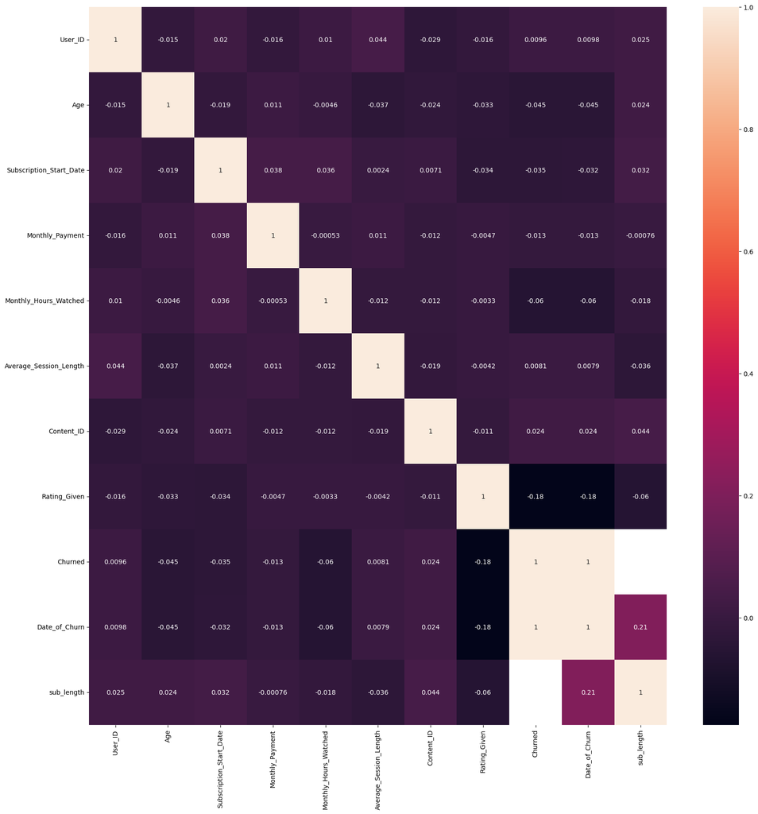

```python
# first look at Heatmap: this will show the linear corealtion of different numerical values
numeric_columns = df.select_dtypes(include=['float64', 'int64', 'datetime64[ns]']).columns
corr_matrix = df[numeric_columns].corr()
plt.figure(figsize = (20,20))
sns.heatmap(df[numeric_columns].corr(), annot=True)
```

Now I will explore further each of the significant corelations to churn

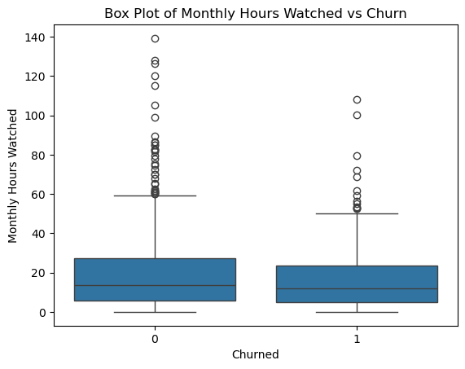

```python
#Monthly Hours Watched
#boxplot of monthy hours watched against churn
# this will show Distribution of monthly hours watched for churned (1) and non-churned (0) users (median, quartiles, and potential outliers)
sns.boxplot(x='Churned', y='Monthly_Hours_Watched', data=df)
plt.title('Box Plot of Monthly Hours Watched vs Churn')
plt.xlabel('Churned')
plt.ylabel('Monthly Hours Watched')
```

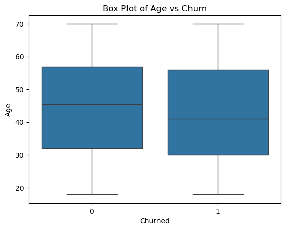

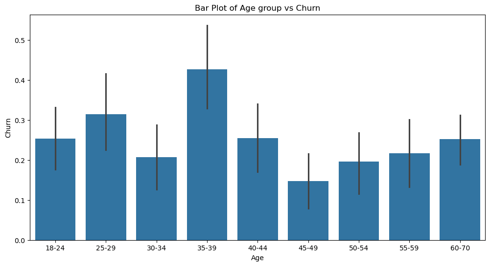

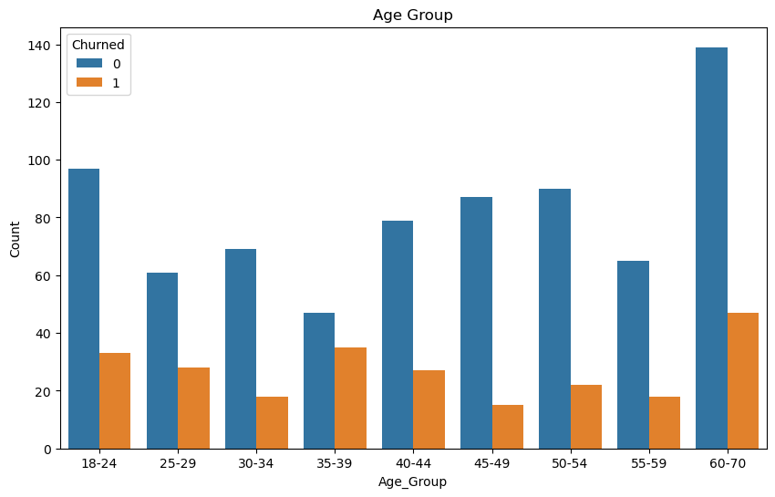

```python
#Age
#boxplot of Age against churn
# this will show Distribution of Age for churned (1) and non-churned (0) users (median, quartiles, and potential outliers)
sns.boxplot(x='Churned', y='Age', data=df)
plt.title('Box Plot of Age vs Churn')
plt.xlabel('Churned')
plt.ylabel('Age')


# I will also Make a box plot with age groups to see if certain age ranges have a greater effect
#Create age groups
bins = [18, 25, 30, 35, 40, 45, 50, 55, 60, 70]
labels = ['18-24', '25-29', '30-34', '35-39', '40-44', '45-49', '50-54', '55-59', '60-70']
df['Age_Group'] = pd.cut(df['Age'], bins=bins, labels=labels, right=False)

#Box plot
plt.figure(figsize=(12, 6))
sns.barplot(data=df, x='Age_Group', y='Churned')
plt.title('Bar Plot of Age group vs Churn')
plt.xlabel('Age')
plt.ylabel('Churn')

#countplot
plt.figure(figsize=(10, 6))
sns.countplot(x='Age_Group', hue='Churned', data=df)
plt.xlabel('Age_Group')
plt.ylabel('Count')
plt.title('Age Group')
```

From this I can conclude

- membership skews towards an older age but our biggest churneres are younger

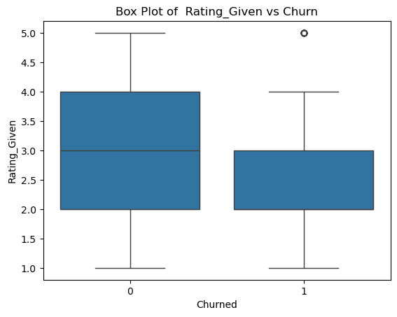

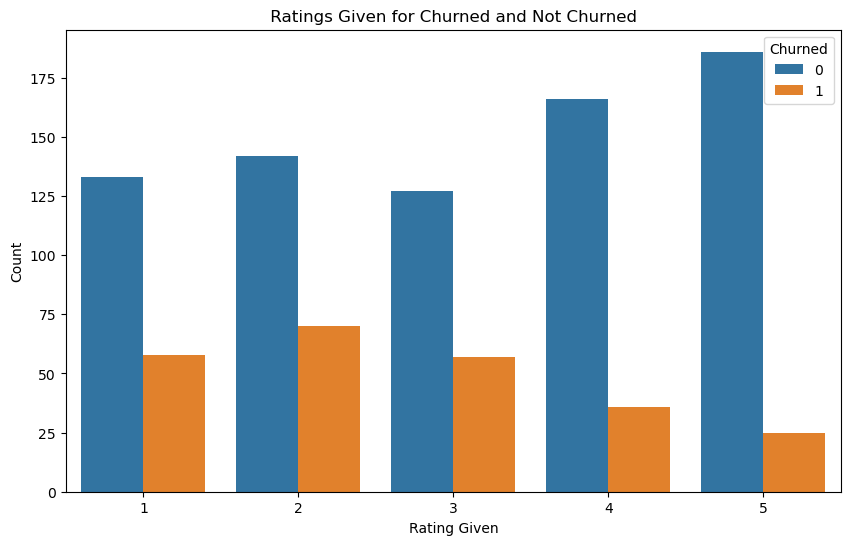

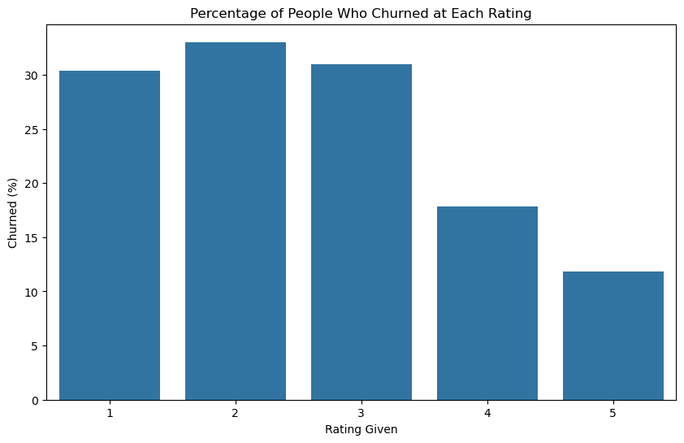

```python
# Rating given
#boxplot of Rating given against churn
# this will show Distribution of Rating Givin for churned (1) and non-churned (0) users (median, quartiles, and potential outliers)
sns.boxplot(x='Churned', y='Rating_Given', data=df)
plt.title('Box Plot of  Rating_Given vs Churn')
plt.xlabel('Churned')
plt.ylabel('Rating_Given')

# hisplot to see the distribution of ratings given for churned and not churned users
plt.figure(figsize=(10, 6))
sns.countplot(x='Rating_Given', hue='Churned', data=df)
plt.title(' Ratings Given for Churned and Not Churned ')
plt.xlabel('Rating Given')
plt.ylabel('Count')

#plot for the ercentage of people who chured at each rating
# percentage of people who churned at each rating
rating_churn_data = df.groupby('Rating_Given')['Churned'].value_counts(normalize=True).unstack() * 100
#NaN values fill with 0
rating_churn_data = rating_churn_data.fillna(0)
# New columns
rating_churn_data.columns = ['Not Churned (%)', 'Churned (%)']

plt.figure(figsize=(10, 6))
sns.barplot(x=rating_churn_data.index, y=rating_churn_data['Churned (%)'])
plt.title('Percentage of People Who Churned at Each Rating')
plt.xlabel('Rating Given')
plt.ylabel('Churned (%)')
```

From this I can conclude that the impact of monthly hoursed watched is small

- median monthly hours watched is higher for non-churned users compared to churned users
- interquartile range wider for non churned showing more variability in the monthly hours watched
- some outliers in the non-churned group with very high monthly hours watched
- a few outliers in churned with high hours watched

Seeing as Monthly houes watched was the largest out of age (-.045) and Subscrition start date (-.035) and had little impact on churn rate I can assume these will also not be significant factors to look further into Although it was not significant in the heatmap I will be looking at monthly payment when I analyze subscrition type in the categorical variables below

I can now look at the categorical variables against churn which include *for each of these I will look at the count of ecah category in churn vs not churn and the rate of churn for each category

- Gender
- Location

-Subscription type

- Payment methid

_ favourite genre

- Device Used

_- reson for churn

I have excuded the user ID and Content Id from evalution

- Content Id will be covered under favourite genre
- user Id is not signifiant to the evaluation but could be used to look at individual cases

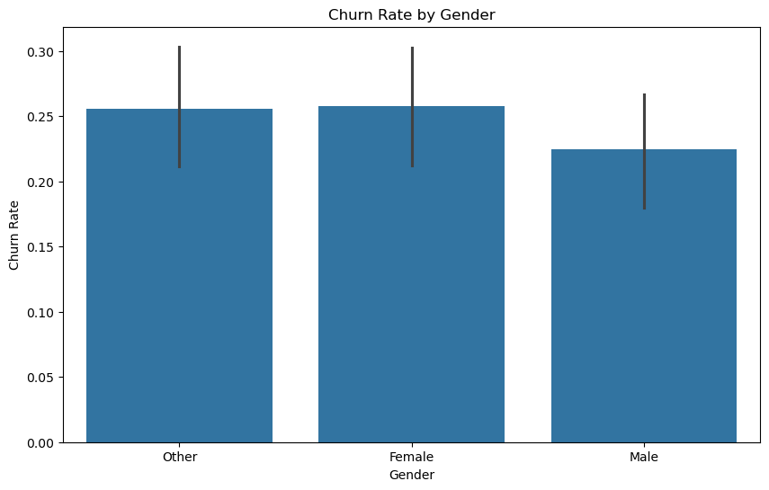

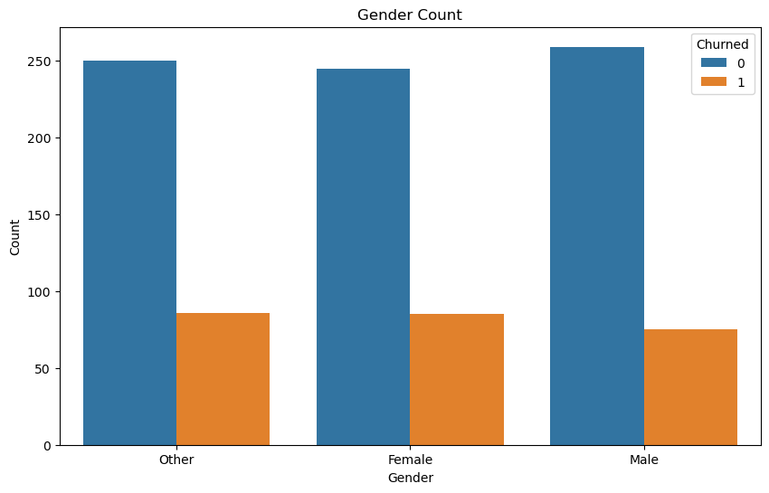

```python
#Gender
# Box Plot 1: Churn Rate by Gender
plt.figure(figsize=(10, 6))
sns.barplot(x='Gender', y='Churned', data=df)
plt.xlabel('Gender')
plt.ylabel('Churn Rate')
plt.title('Churn Rate by Gender')

# Plot 2: Count of Churned and Not Churned by Gender
plt.figure(figsize=(10, 6))
sns.countplot(x='Gender', hue='Churned', data=df)
plt.xlabel('Gender')
plt.ylabel('Count')
plt.title('Gender Count')
```

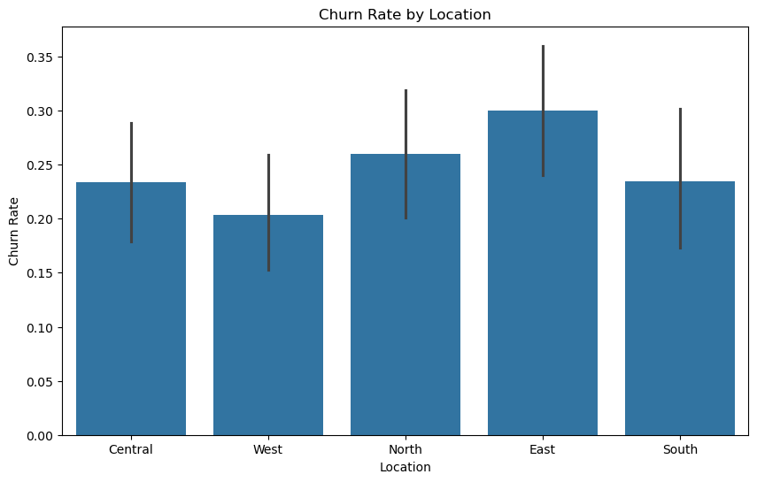

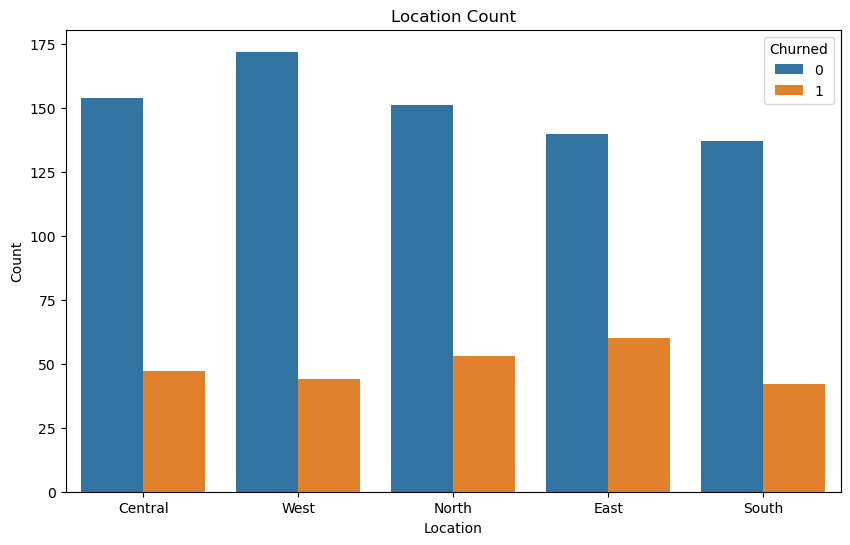

```python
#Location
# Box Plot 1: Churn Rate by Location
plt.figure(figsize=(10, 6))
sns.barplot(x='Location', y='Churned', data=df)
plt.xlabel('Location')
plt.ylabel('Churn Rate')
plt.title('Churn Rate by Location')

# Plot 2: Count of Churned and Not Churned by Location
plt.figure(figsize=(10, 6))
sns.countplot(x='Location', hue='Churned', data=df)
plt.xlabel('Location')
plt.ylabel('Count')
plt.title('Location Count')
```

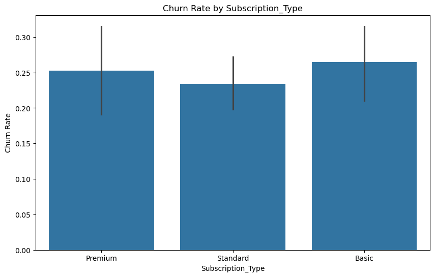

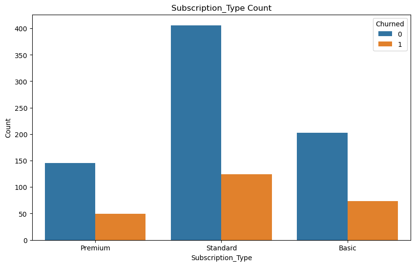

```python
#Subscritpion Type
# Box Plot 1: Churn Rate by Sub type
plt.figure(figsize=(10, 6))
sns.barplot(x='Subscription_Type', y='Churned', data=df)
plt.xlabel('Subscription_Type')
plt.ylabel('Churn Rate')
plt.title('Churn Rate by Subscription_Type')

# Plot 2: Count of Churned and Not Churned by Subscription Type
plt.figure(figsize=(10, 6))
sns.countplot(x='Subscription_Type', hue='Churned', data=df)
plt.xlabel('Subscription_Type')
plt.ylabel('Count')
plt.title('Subscription_Type Count')
```

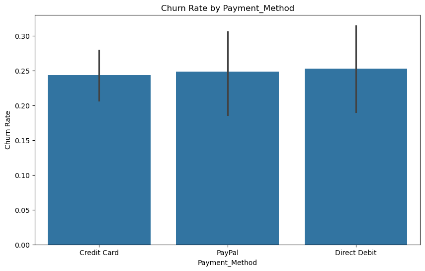

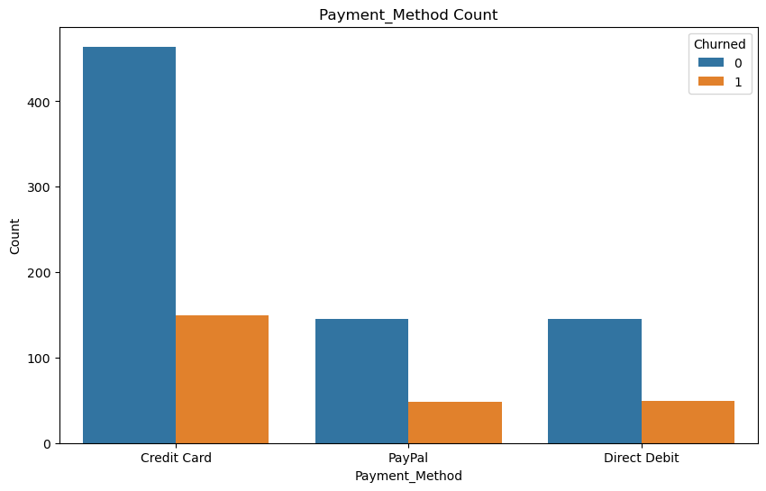

```python
#Payment Method
# Box Plot 1: Churn Rate by Payment_Method
plt.figure(figsize=(10, 6))
sns.barplot(x='Payment_Method', y='Churned', data=df)
plt.xlabel('Payment_Method')
plt.ylabel('Churn Rate')
plt.title('Churn Rate by Payment_Method')

# Plot 2: Count of Churned and Not Churned by Subscription Type
plt.figure(figsize=(10, 6))
sns.countplot(x='Payment_Method', hue='Churned', data=df)
plt.xlabel('Payment_Method')
plt.ylabel('Count')
plt.title('Payment_Method Count')
```

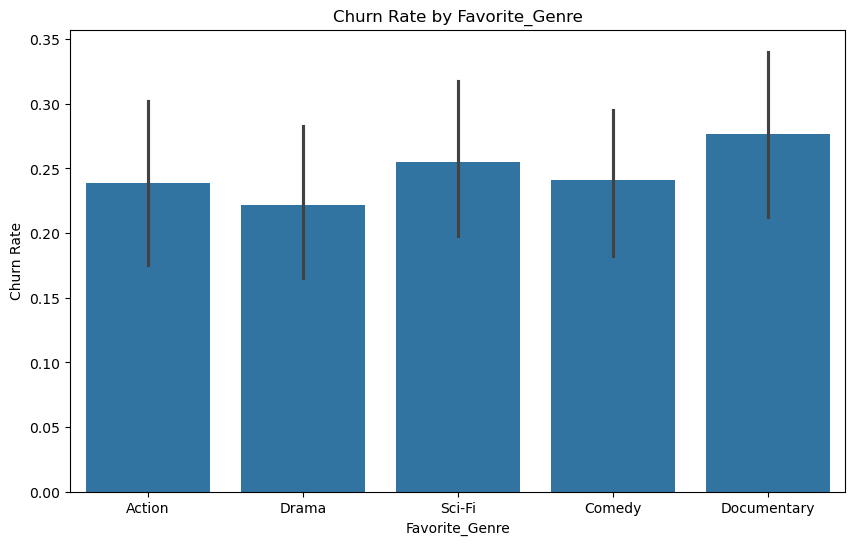

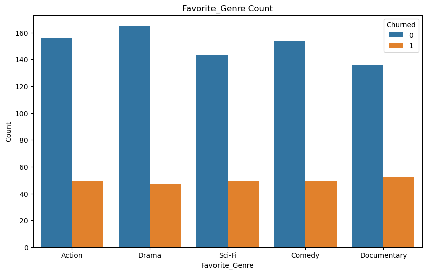

```python
#Favorite_Genre
# Box Plot 1: Churn Rate by Favorite_Genre
plt.figure(figsize=(10, 6))
sns.barplot(x='Favorite_Genre', y='Churned', data=df)
plt.xlabel('Favorite_Genre')
plt.ylabel('Churn Rate')
plt.title('Churn Rate by Favorite_Genre')

# Plot 2: Count of Churned and Not Churned by Favorite_Genre
plt.figure(figsize=(10, 6))
sns.countplot(x='Favorite_Genre', hue='Churned', data=df)
plt.xlabel('Favorite_Genre')
plt.ylabel('Count')
plt.title('Favorite_Genre Count')
```

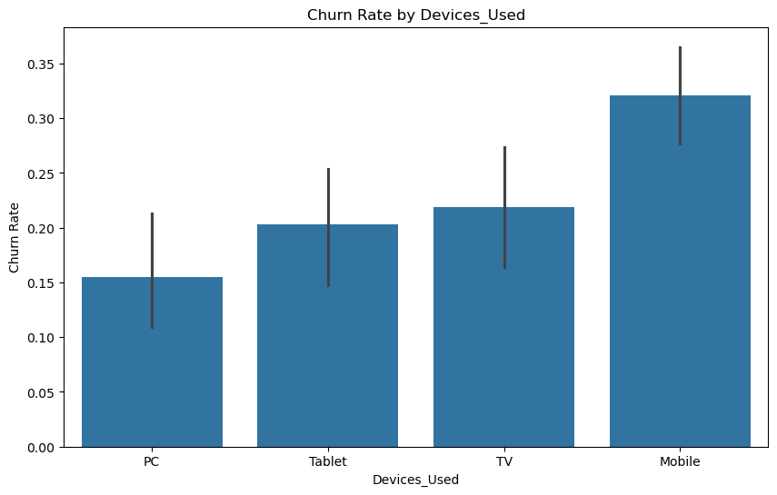

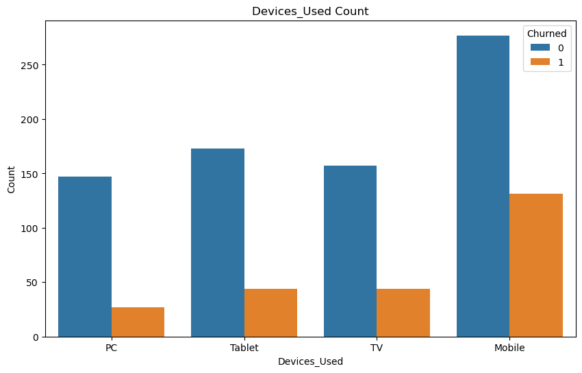

```python
#Devices_Used
# Box Plot 1: Churn Rate by Devices_Used
plt.figure(figsize=(10, 6))
sns.barplot(x='Devices_Used', y='Churned', data=df)
plt.xlabel('Devices_Used')
plt.ylabel('Churn Rate')
plt.title('Churn Rate by Devices_Used')

# Plot 2: Count of Churned and Not Churned by Devices_Used
plt.figure(figsize=(10, 6))
sns.countplot(x='Devices_Used', hue='Churned', data=df)
plt.xlabel('Devices_Used')
plt.ylabel('Count')
plt.title('Devices_Used Count')
```

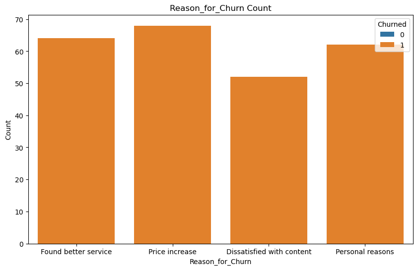

```python
#Reason_for_Churn
# Only visualized with the count of churn as the churn rate and reason for churn is 1 to 1
# Plot 2: Count of Churned and Not Churned by Reason_for_Churn
plt.figure(figsize=(10, 6))
sns.countplot(x='Reason_for_Churn', hue='Churned', data=df)
plt.xlabel('Reason_for_Churn')
plt.ylabel('Count')
plt.title('Reason_for_Churn Count')
```

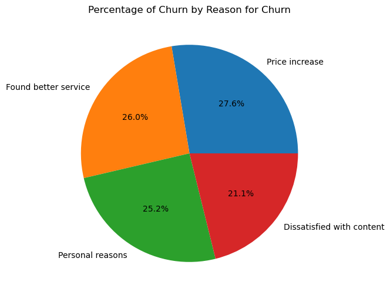

```python
#Reason_for_Churn
# I will use a pie chart to see how the different reasons for churn contribute to the total churn value

#Include only churned users
churned_users = df[df['Churned'] == 1]
#Percentage of each reason for churn, excluding NaN values
Reason_Count = churned_users['Reason_for_Churn'].dropna().value_counts()
Reason_Percentages = (Reason_Count / Reason_Count.sum()) * 100
# Create a pie
plt.figure(figsize=(10, 6))
plt.pie(Reason_Percentages, labels=Reason_Percentages.index, autopct='%1.1f%%')
plt.title('Percentage of Churn by Reason for Churn')
```